# Final Project Report

Jiayi Li, Shengkai Zheng, Tianyi Hong

Dec, 14, 2021

From 1-20-2021 to 11-10-2021，Which region of the United States (the Northeast, South, West, and Midwest) deals COVID-19 better based on the vaccination rate and Covid-19 cases?

Ever since March 2020, the coronavirus pandemic has affected our lives and nearly every corner of the globe. Coronavirus has also been many people’s concern because of its high transmission rate and fatality rate, compared to other infectious diseases. The infected rate of Coronavirus depends on many elements: contact rate, recovery rate, number of people getting vaccinated, and so on. Therefore, the growth of Coronavirus can vary from country to country, region to region, and even weeks to weeks depending on those elements.In this project, we think it is interesting to investigate the growth of Coronavirus with the number of people getting vaccinated in the U.S, and with numerous data related to coronavirus pandemic, we believe that we can get some meaningful insights. More specifically, we came up with the research question: “From 1-20-2021 to 11-10-2021, Which region of United States (the Northeast, South, West, and Midwest) deals COVID-19 better based the vaccination rate and Covid-19 cases?”

### Clean Up Environment and Load Libraries

```r
rm(list = ls())
library(tidyverse)
library(dbplyr)
library(ggplot2)
library(lubridate)
```

### Data Intake

```r
StateVaccination <- read.csv("state_vaccination.csv")
```

```r
CovidCases <- read_csv("United_States_COVID-19_Cases_and_Deaths_by_State_over_Time.csv")
```

### Inspect data intake

- Inspect the StateVaccination data frame

The data set StateVaccination is a state-by-state data on United States COVID-19 vaccinations, and is created by *our world in data website* which rely on the data updated daily by the United States Centers for Disease Control and Prevention. Their intention is to “maintain the database for the foreseeable future and include additional countries as they implement their vaccination campaigns”.This data set is first created on 1/12/2021 and contains data of vaccination related data for each states/federal entity.

```r
StateVaccination %>%
  head()
```

|  | date | location | total_vaccinations | total_distributed | people_vaccinated | people_fully_vaccinated_per_hundred | total_vaccinations_per_hundred | people_fully_vaccinated | people_vaccinated_per_hundred | distributed_per_hundred | daily_vaccinations_raw | daily_vaccinations | daily_vaccinations_per_million | share_doses_used |
| --- | --- | --- | --- | --- | --- | --- | --- | --- | --- | --- | --- | --- | --- | --- |
| 1 | 2021-01-12 | Alabama | 78134 | 377025 | 70861 | 0.15 | 1.59 | 7270 | 1.45 | 7.69 | NA | NA | NA | 0.207 |
| 2 | 2021-01-13 | Alabama | 84040 | 378975 | 74792 | 0.19 | 1.71 | 9245 | 1.53 | 7.73 | 5906 | 5906 | 1205 | 0.222 |
| 3 | 2021-01-14 | Alabama | 92300 | 435350 | 80480 | NA | 1.88 | NA | 1.64 | 8.88 | 8260 | 7083 | 1445 | 0.212 |
| 4 | 2021-01-15 | Alabama | 100567 | 444650 | 86956 | 0.28 | 2.05 | 13488 | 1.77 | 9.07 | 8267 | 7478 | 1525 | 0.226 |
| 5 | 2021-01-16 | Alabama | NA | NA | NA | NA | NA | NA | NA | NA | NA | 7498 | 1529 | NA |
| 6 | 2021-01-17 | Alabama | NA | NA | NA | NA | NA | NA | NA | NA | NA | 7509 | 1531 | NA |

```r
StateVaccination %>%
    str()
```

```
'data.frame':   19551 obs. of  14 variables:
 $ date                               : chr  "2021-01-12" "2021-01-13" "2021-01-14" "2021-01-15" ...
 $ location                           : chr  "Alabama" "Alabama" "Alabama" "Alabama" ...
 $ total_vaccinations                 : num  78134 84040 92300 100567 NA ...
 $ total_distributed                  : num  377025 378975 435350 444650 NA ...
 $ people_vaccinated                  : num  70861 74792 80480 86956 NA ...
 $ people_fully_vaccinated_per_hundred: num  0.15 0.19 NA 0.28 NA NA NA 0.33 0.37 0.44 ...
 $ total_vaccinations_per_hundred     : num  1.59 1.71 1.88 2.05 NA NA NA 2.67 2.84 3.38 ...
 $ people_fully_vaccinated            : num  7270 9245 NA 13488 NA ...
 $ people_vaccinated_per_hundred      : num  1.45 1.53 1.64 1.77 NA NA NA 2.33 2.47 2.95 ...
 $ distributed_per_hundred            : num  7.69 7.73 8.88 9.07 NA ...
 $ daily_vaccinations_raw             : num  NA 5906 8260 8267 NA ...
 $ daily_vaccinations                 : num  NA 5906 7083 7478 7498 ...
 $ daily_vaccinations_per_million     : num  NA 1205 1445 1525 1529 ...
 $ share_doses_used                   : num  0.207 0.222 0.212 0.226 NA NA NA 0.294 0.288 0.336 ...
```

```r
StateVaccination %>%
    glimpse()
```

```
Rows: 19,551
Columns: 14
$ date                                <chr> "2021-01-12", "2021-01-13", "2021-01-14", "2021-01-15", "2021-01-16"…
$ location                            <chr> "Alabama", "Alabama", "Alabama", "Alabama", "Alabama", "Alabama", "A…
$ total_vaccinations                  <dbl> 78134, 84040, 92300, 100567, NA, NA, NA, 130795, 139200, 165919, 199…
$ total_distributed                   <dbl> 377025, 378975, 435350, 444650, NA, NA, NA, 444650, 483275, 493125, …
$ people_vaccinated                   <dbl> 70861, 74792, 80480, 86956, NA, NA, NA, 114319, 121113, 144429, 1743…
$ people_fully_vaccinated_per_hundred <dbl> 0.15, 0.19, NA, 0.28, NA, NA, NA, 0.33, 0.37, 0.44, 0.51, 0.56, 0.61…
$ total_vaccinations_per_hundred      <dbl> 1.59, 1.71, 1.88, 2.05, NA, NA, NA, 2.67, 2.84, 3.38, 4.06, 4.52, 4.…
$ people_fully_vaccinated             <dbl> 7270, 9245, NA, 13488, NA, NA, NA, 16346, 17956, 21345, 24840, 27422…
$ people_vaccinated_per_hundred       <dbl> 1.45, 1.53, 1.64, 1.77, NA, NA, NA, 2.33, 2.47, 2.95, 3.56, 3.96, 4.…
$ distributed_per_hundred             <dbl> 7.69, 7.73, 8.88, 9.07, NA, NA, NA, 9.07, 9.86, 10.06, 10.60, 10.63,…
$ daily_vaccinations_raw              <dbl> NA, 5906, 8260, 8267, NA, NA, NA, NA, 8405, 26719, 33395, 22226, 221…
$ daily_vaccinations                  <dbl> NA, 5906, 7083, 7478, 7498, 7509, 7517, 7523, 7880, 10517, 14107, 16…
$ daily_vaccinations_per_million      <dbl> NA, 1205, 1445, 1525, 1529, 1531, 1533, 1534, 1607, 2145, 2877, 3304…
$ share_doses_used                    <dbl> 0.207, 0.222, 0.212, 0.226, NA, NA, NA, 0.294, 0.288, 0.336, 0.384, …
```

- Inspect the CovidCases data frame

The data set CovidCases is found on DATA.GOV website, and it is created by CDC. CDC reports aggregate counts of COVID-19 cases and death numbers daily online. Data on the COVID-19 website and CDC’s COVID Data Tracker are based on these most recent numbers reported by states, territories, and other jurisdictions. This data set of “United States COVID-19 Cases and Deaths by State over Time” combines this information. However, data are dependent on jurisdictions’ timely and accurate reporting. This data set is first created on November 10, 2020.

```r
CovidCases %>%
  head()
```

| submission_date | state | tot_cases | conf_cases | prob_cases | new_case | pnew_case | tot_death | conf_death | prob_death | new_death | pnew_death | created_at | consent_cases | consent_deaths |
| --- | --- | --- | --- | --- | --- | --- | --- | --- | --- | --- | --- | --- | --- | --- |
| 09/01/2021 | ND | 118491 | 107475 | 11016 | 536 | 66 | 1562 | NA | NA | 1 | 0 | 09/02/2021 01:49:05 PM | Agree | Not agree |
| 07/14/2020 | CA | 336447 | 336447 | 0 | 7285 | 0 | 7039 | 7039 | 0 | 25 | 0 | 07/16/2020 12:00:00 AM | Agree | Agree |
| 02/02/2021 | IL | 1130917 | 1130917 | 0 | 2304 | 0 | 21336 | 19306 | 2030 | 63 | 16 | 02/03/2021 02:55:58 PM | Agree | Agree |
| 09/19/2021 | DE | 128253 | 117969 | 10284 | 450 | 36 | 1920 | 1756 | 164 | 0 | 0 | 09/20/2021 01:47:59 PM | Agree | Agree |
| 06/15/2020 | WI | 25480 | 22932 | 2548 | 185 | 11 | 700 | 694 | 6 | 2 | 0 | 06/16/2020 02:10:11 PM | Agree | Agree |
| 07/31/2020 | ND | 6602 | 6602 | 0 | 133 | 0 | 103 | NA | NA | 0 | 0 | 08/01/2020 02:38:12 PM | Agree | Not agree |

```r
NA
```

```r
CovidCases %>%
    str()
```

```
spec_tbl_df [39,540 × 15] (S3: spec_tbl_df/tbl_df/tbl/data.frame)
 $ submission_date: chr [1:39540] "09/01/2021" "07/14/2020" "02/02/2021" "09/19/2021" ...
 $ state          : chr [1:39540] "ND" "CA" "IL" "DE" ...
 $ tot_cases      : num [1:39540] 118491 336447 1130917 128253 25480 ...
 $ conf_cases     : num [1:39540] 107475 336447 1130917 117969 22932 ...
 $ prob_cases     : num [1:39540] 11016 0 0 10284 2548 ...
 $ new_case       : num [1:39540] 536 7285 2304 450 185 ...
 $ pnew_case      : num [1:39540] 66 0 0 36 11 0 0 256 450 NA ...
 $ tot_death      : num [1:39540] 1562 7039 21336 1920 700 ...
 $ conf_death     : num [1:39540] NA 7039 19306 1756 694 ...
 $ prob_death     : num [1:39540] NA 0 2030 164 6 ...
 $ new_death      : num [1:39540] 1 25 63 0 2 0 0 29 16 0 ...
 $ pnew_death     : num [1:39540] 0 0 16 0 0 0 0 8 2 NA ...
 $ created_at     : chr [1:39540] "09/02/2021 01:49:05 PM" "07/16/2020 12:00:00 AM" "02/03/2021 02:55:58 PM" "09/20/2021 01:47:59 PM" ...
 $ consent_cases  : chr [1:39540] "Agree" "Agree" "Agree" "Agree" ...
 $ consent_deaths : chr [1:39540] "Not agree" "Agree" "Agree" "Agree" ...
 - attr(*, "spec")=
  .. cols(
  ..   submission_date = col_character(),
  ..   state = col_character(),
  ..   tot_cases = col_double(),
  ..   conf_cases = col_double(),
  ..   prob_cases = col_double(),
  ..   new_case = col_double(),
  ..   pnew_case = col_double(),
  ..   tot_death = col_double(),
  ..   conf_death = col_double(),
  ..   prob_death = col_double(),
  ..   new_death = col_double(),
  ..   pnew_death = col_double(),
  ..   created_at = col_character(),
  ..   consent_cases = col_character(),
  ..   consent_deaths = col_character()
  .. )
 - attr(*, "problems")=<externalptr>
```

```r
CovidCases %>%
    glimpse()
```

```
Rows: 39,540
Columns: 15
$ submission_date <chr> "09/01/2021", "07/14/2020", "02/02/2021", "09/19/2021", "06/15/2020", "07/31/2020", "08/…
$ state           <chr> "ND", "CA", "IL", "DE", "WI", "ND", "GU", "AL", "NC", "MI", "CT", "ND", "NV", "MI", "CT"…
$ tot_cases       <dbl> 118491, 336447, 1130917, 128253, 25480, 6602, 449, 492393, 875359, 0, 36085, 129472, 399…
$ conf_cases      <dbl> 107475, 336447, 1130917, 117969, 22932, 6602, NA, 388404, 760095, NA, 34059, 114734, 399…
$ prob_cases      <dbl> 11016, 0, 0, 10284, 2548, 0, NA, 103989, 115264, NA, 2026, 14738, 0, NA, 1810, NA, NA, N…
$ new_case        <dbl> 536, 7285, 2304, 450, 185, 133, 15, 903, 1614, 0, 621, 142, 1446, 0, 211, 779, 3669, 172…
$ pnew_case       <dbl> 66, 0, 0, 36, 11, 0, 0, 256, 450, NA, -11, 45, 0, NA, -30, 0, 0, 402, 76, 49, 0, 322, 51…
$ tot_death       <dbl> 1562, 7039, 21336, 1920, 700, 103, 5, 10523, 12363, 0, 3285, 1604, 6637, 0, 3008, 2888, …
$ conf_death      <dbl> NA, 7039, 19306, 1756, 694, NA, NA, 8396, 10933, NA, 2524, NA, NA, NA, 2294, 2692, 8640,…
$ prob_death      <dbl> NA, 0, 2030, 164, 6, NA, NA, 2127, 1430, NA, 761, NA, NA, NA, 714, 196, 327, NA, 2283, N…
$ new_death       <dbl> 1, 25, 63, 0, 2, 0, 0, 29, 16, 0, 66, 0, 33, 0, 41, 12, 85, 7, 4, 0, 0, 45, 30, 9, 14, 4…
$ pnew_death      <dbl> 0, 0, 16, 0, 0, 0, 0, 8, 2, NA, 8, 0, 0, NA, -10, 1, 1, 0, 2, 0, 0, 2, 4, 5, 0, 0, 0, 0,…
$ created_at      <chr> "09/02/2021 01:49:05 PM", "07/16/2020 12:00:00 AM", "02/03/2021 02:55:58 PM", "09/20/202…
$ consent_cases   <chr> "Agree", "Agree", "Agree", "Agree", "Agree", "Agree", "Not agree", "Agree", "Agree", "Ag…
$ consent_deaths  <chr> "Not agree", "Agree", "Agree", "Agree", "Agree", "Not agree", "Not agree", "Agree", "Agr…
```

### Data Wrangling and Cleaning

1. StateVaccination
- The variable location has some invalid value. Here we eliminate invalid value from location by using a filter.

```r
states <-list("Alabama","Alaska","Arizona", "Arkansas", "California", "Colorado", "Connecticut", "Delaware","Florida", "Georgia", "Hawaii", "Idaho", "Illinois", "Indiana", "Iowa", "Kansas", "Kentucky", "Louisiana","Maine", "Maryland","Massachusetts","Michigan","Minnesota","Mississippi","Missouri","Montana","Nebraska", "Nevada", "New Hampshire","New Jersey", "New Mexico", "New York State", "North Carolina", "North Dakota", "Ohio", "Oklahoma", "Oregon", "Pennsylvania", "Rhode Island", "South Carolina", "South Dakota", "Tennessee", "Texas", "Utah", "Vermont", "Virginia",  "Washington", "West Virginia", "Wisconsin","Wyoming")

# eliminate all the invalid value in states
StateVaccination <-
  StateVaccination %>%
  filter( location %in% states)

# all the unique value in states
StateVaccination %>%
  select(location) %>%
  unique() %>%
  head()
```

|  | location |
| --- | --- |
| 1 | Alabama |
| 309 | Alaska |
| 614 | Arizona |
| 921 | Arkansas |
| 1230 | California |
| 1539 | Colorado |

```r
# here we change New York State to New York.
StateVaccination <-
  StateVaccination %>%
  mutate(location = ifelse(location == "New York State", "New York", location))

StateVaccination %>%
  select(location) %>%
  head()
```

|  | location |
| --- | --- |
| 1 | Alabama |
| 2 | Alabama |
| 3 | Alabama |
| 4 | Alabama |
| 5 | Alabama |
| 6 | Alabama |

- The variabke date need to be in the interval 2021-1-12 to 2021-11-10

```r
StateVaccination <-
StateVaccination %>%
  filter(date <= ymd("2021-11-10"))
```

- We create a new variable called month based on date

```r
StateVaccination <-
StateVaccination %>%
  mutate(month = month(date))
```

- We create a Dataframe called CleanedStateVaccination that contain month, location, and a new variable called peopleVaccinated that contain the total number of people get vaccinated each month. Since the variable people_vaccinated is cumulative. We simply group by month and location and subtract the max people_vaccinated and min people_vaccinated to get the number of people get vaccinated each month.

```r
CleanedStateVaccination <-
  StateVaccination %>%
  group_by(month, location) %>%
  summarize(peopleVaccinatedMonthly = max(people_vaccinated, na.rm = TRUE)-min(people_vaccinated, na.rm = TRUE))
```

```r
CleanedStateVaccination %>% head()
```

| month | location | peopleVaccinatedMonthly |
| --- | --- | --- |
| 1 | Alabama | 227440 |
| 1 | Alaska | 72403 |
| 1 | Arizona | 405801 |
| 1 | Arkansas | 205510 |
| 1 | California | 2013990 |
| 1 | Colorado | 252738 |

2. CovidCases
- We create attribute called month based on submission date

The variable submission date indicates the date that the data was submitted and recorded of. It is originally character data type, so we first convert it to date date type. Then we create a new attribute called month, taking the month extracted from date.

```r
# create variable month

  CovidCases<-
  CovidCases %>%
  mutate(month = str_extract(string = submission_date, pattern = "(^[0-9]{2})")) %>%
  mutate(date = mdy(submission_date)) %>%
  filter(date > mdy("12-31-2020")) %>%
  arrange(submission_date)

CovidCases %>%
    head()
```

| submission_date | state | tot_cases | conf_cases | prob_cases | new_case | pnew_case | tot_death | conf_death | prob_death | new_death | pnew_death | created_at | consent_cases | consent_deaths | month | date |
| --- | --- | --- | --- | --- | --- | --- | --- | --- | --- | --- | --- | --- | --- | --- | --- | --- |
| 01/01/2021 | WI | 522523 | 483007 | 39516 | 2085 | 180 | 5254 | 4869 | 385 | 12 | 2 | 01/02/2021 02:50:51 PM | Agree | Agree | 01 | 2021-01-01 |
| 01/01/2021 | ND | 92891 | 89829 | 3062 | 121 | 22 | 1310 | NA | NA | 1 | 0 | 01/02/2021 02:50:51 PM | Agree | Not agree | 01 | 2021-01-01 |
| 01/01/2021 | MS | 223753 | 151719 | 72034 | 1825 | 1103 | 5674 | 4242 | 1432 | 28 | 14 | 01/03/2021 12:00:00 AM | Agree | Agree | 01 | 2021-01-01 |
| 01/01/2021 | MO | 450801 | NA | NA | 1232 | 223 | 6899 | NA | NA | 43 | 0 | 01/03/2021 12:00:00 AM | Not agree | Not agree | 01 | 2021-01-01 |
| 01/01/2021 | MI | 591739 | 543597 | 48142 | 2011 | 166 | 13916 | 13131 | 785 | 100 | 7 | 01/02/2021 12:00:00 AM | Agree | Agree | 01 | 2021-01-01 |
| 01/01/2021 | IN | 517998 | NA | NA | 6300 | 0 | 9940 | 9593 | 347 | 88 | 1 | 01/01/2021 12:00:00 AM | Not agree | Agree | 01 | 2021-01-01 |

```r
# change month to numeric data type
CovidCases <-
CovidCases %>%
    mutate(month = as.numeric(unlist(month)))

CovidCases %>%
    head()
```

| submission_date | state | tot_cases | conf_cases | prob_cases | new_case | pnew_case | tot_death | conf_death | prob_death | new_death | pnew_death | created_at | consent_cases | consent_deaths | month | date |
| --- | --- | --- | --- | --- | --- | --- | --- | --- | --- | --- | --- | --- | --- | --- | --- | --- |
| 01/01/2021 | WI | 522523 | 483007 | 39516 | 2085 | 180 | 5254 | 4869 | 385 | 12 | 2 | 01/02/2021 02:50:51 PM | Agree | Agree | 1 | 2021-01-01 |
| 01/01/2021 | ND | 92891 | 89829 | 3062 | 121 | 22 | 1310 | NA | NA | 1 | 0 | 01/02/2021 02:50:51 PM | Agree | Not agree | 1 | 2021-01-01 |
| 01/01/2021 | MS | 223753 | 151719 | 72034 | 1825 | 1103 | 5674 | 4242 | 1432 | 28 | 14 | 01/03/2021 12:00:00 AM | Agree | Agree | 1 | 2021-01-01 |
| 01/01/2021 | MO | 450801 | NA | NA | 1232 | 223 | 6899 | NA | NA | 43 | 0 | 01/03/2021 12:00:00 AM | Not agree | Not agree | 1 | 2021-01-01 |
| 01/01/2021 | MI | 591739 | 543597 | 48142 | 2011 | 166 | 13916 | 13131 | 785 | 100 | 7 | 01/02/2021 12:00:00 AM | Agree | Agree | 1 | 2021-01-01 |
| 01/01/2021 | IN | 517998 | NA | NA | 6300 | 0 | 9940 | 9593 | 347 | 88 | 1 | 01/01/2021 12:00:00 AM | Not agree | Agree | 1 | 2021-01-01 |

- transform state attribute to contain full name

In the primary source, location contains full state name. Thus, to facilitate operation on these two data source, we choose to make state attribute to contain full states’ name.

Here we leverage on the abbr2state function that is provided by the usdata package

```r
library(usdata)
```

```r
CovidCases <-
  CovidCases %>%
  mutate(state = abbr2state(state))

CovidCases %>%
  select(state) %>%
  unique() %>%
  head()
```

| state |
| --- |
| Wisconsin |
| North Dakota |
| Mississippi |
| Missouri |
| Michigan |
| Indiana |

```r
NA
```

```r
states <-list("Alabama","Alaska","Arizona", "Arkansas", "California", "Colorado", "Connecticut", "Delaware","Florida", "Georgia", "Hawaii", "Idaho", "Illinois", "Indiana", "Iowa", "Kansas", "Kentucky", "Louisiana","Maine", "Maryland","Massachusetts","Michigan","Minnesota","Mississippi","Missouri","Montana","Nebraska", "Nevada", "New Hampshire","New Jersey", "New Mexico", "New York", "North Carolina", "North Dakota", "Ohio", "Oklahoma", "Oregon", "Pennsylvania", "Rhode Island", "South Carolina", "South Dakota", "Tennessee", "Texas", "Utah", "Vermont", "Virginia",  "Washington", "West Virginia", "Wisconsin","Wyoming")

CovidCases <-
CovidCases %>%
  filter(state %in% states)

CovidCases %>% select(state) %>%
  unique() %>%
  head()
```

| state |
| --- |
| Wisconsin |
| North Dakota |
| Mississippi |
| Missouri |
| Michigan |
| Indiana |

- Here we eliminate negative value in new cases and aggregate it into monthly new cases

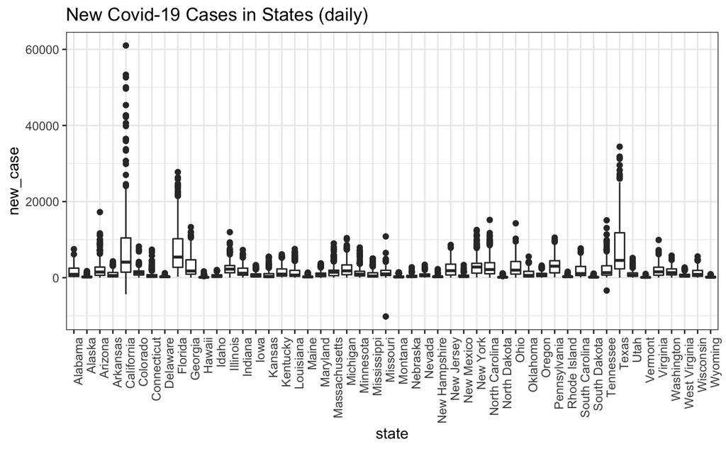

```r
CovidCases %>%
  ggplot(aes(x= state, y = new_case)) +
  geom_boxplot() +
  theme_bw() +
  theme(axis.text.x = element_text(angle = 90, hjust = 1)) +
  ggtitle("New Covid-19 Cases in States (daily) ")
```

There are some outliers in the new_case column: we notice that for state like MO and TN, there are some negative value in the new_case column. There is no further information about this attributes provided by the data source. Thus, we take a closer look on our own.

from the following result, we can see the new_case for 06/30/2021 is negative: -4359. Meanwhile, the tot_cases for 06/30/2021 is 3710454, 4359 less than tot_cases for 06/29/2021. Thus we can conclude that new_case also account for people that are recovered from COVID-19. So we decide to eliminate the negative value and leave the rest like that since the recover portion is relatively small compared to infected portion. It will not disturb our final results.

```r
 CovidCases %>%
   filter(state == "California") %>%
   filter(date == mdy("6-30-2021")| date == mdy("6-29-2021"))
```

| submission_date | state | tot_cases | conf_cases | prob_cases | new_case | pnew_case | tot_death | conf_death | prob_death | new_death | pnew_death | created_at | consent_cases | consent_deaths | month | date |
| --- | --- | --- | --- | --- | --- | --- | --- | --- | --- | --- | --- | --- | --- | --- | --- | --- |
| 06/29/2021 | California | 3714813 | 3714813 | 0 | 762 | 0 | 62999 | 62999 | 0 | 5 | 0 | 07/01/2021 12:00:00 AM | Agree | Agree | 6 | 2021-06-29 |
| 06/30/2021 | California | 3710454 | 3710454 | 0 | -4359 | 0 | 63023 | 63023 | 0 | 24 | 0 | 07/02/2021 12:00:00 AM | Agree | Agree | 6 | 2021-06-30 |

```r
CovidCases<-
CovidCases %>%
  mutate(new_case = ifelse(new_case < 0, 0, new_case))

CovidCases %>%
  filter(new_case < 0)
```

| submission_date | state | tot_cases | conf_cases | prob_cases | new_case | pnew_case | tot_death | conf_death | prob_death | new_death | pnew_death | created_at | consent_cases | consent_deaths | month | date |
| --- | --- | --- | --- | --- | --- | --- | --- | --- | --- | --- | --- | --- | --- | --- | --- | --- |

```r
NA
```

- Here we create CleanCovidCases DataFrame that contain state, month, and monthlyNewCases.

```r
CleanCovidCases <-
CovidCases %>%
  group_by(state, month) %>%
  summarize(monthlyNewCases = sum(new_case, na.rm = TRUE))
CleanCovidCases %>%
  head()
```

| state | month | monthlyNewCases |
| --- | --- | --- |
| Alabama | 1 | 97187 |
| Alabama | 2 | 33900 |
| Alabama | 3 | 22512 |
| Alabama | 4 | 12849 |
| Alabama | 5 | 15769 |
| Alabama | 6 | 5598 |

- Here we create dataframe called CombinedData by joining CleanedStateVaccination and CleanCovidCaes.

```r
CombinedData <-
CleanedStateVaccination %>%
    rename(state = location) %>%
    inner_join(CleanCovidCases, by = c("month", "state"))
CombinedData %>%
    head()
```

| month | state | peopleVaccinatedMonthly | monthlyNewCases |
| --- | --- | --- | --- |
| 1 | Alabama | 227440 | 97187 |
| 1 | Alaska | 72403 | 6991 |
| 1 | Arizona | 405801 | 238290 |
| 1 | Arkansas | 205510 | 70130 |
| 1 | California | 2013990 | 1011796 |
| 1 | Colorado | 252738 | 59309 |

- Here we classify each state into four region: northeast, midwest, south, and west using the self-defined function: convertToRegion

```r
northeast<- c("Connecticut","Maine","Massachusetts","New Hampshire", "Rhode Island", "Vermont", "New Jersey", "New York", "Pennsylvania")

midwest <- c("Illinois", "Indiana", "Michigan", "Ohio", "Wisconsin", "Iowa", "Kansas", "Minnesota", "Missouri", "Nebraska", "North Dakota","South Dakota")

south <- c("Delaware", "Florida",  "Georgia", "Maryland", "North Carolina", "South Carolina", "Virginia", "Washington",  "West Virginia", "Alabama", "Kentucky", "Mississippi", "Tennessee", "Arkansas", "Louisiana", "Oklahoma", "Texas")

west <- c("Arizona", "Colorado", "Idaho", "Montana", "Nevada", "New Mexico", "Utah", "Wyoming","Alaska", "California", "Hawaii", "Oregon","Washington")




convertToRegion <- function(data){
  for(i in 1:nrow(data)) {       # for-loop over columns
  if (data[ i,2 ] %in% northeast){
    data[i,2] <-"Northeast"
  }else if (data[ i,2 ] %in% midwest){
    data[i,2] <-"Midwest"
  }else if (data[ i,2 ] %in% south){
    data[i,2] <-"South"
  }else if (data[ i,2 ] %in% west){
    data[i,2] <-"West"
  }


  }
  return(data)
}
```

```r
RegionData = CombinedData
```

```r
RegionData = convertToRegion(RegionData)
```

```r
RegionData %>%head()
```

| month | state | peopleVaccinatedMonthly | monthlyNewCases |
| --- | --- | --- | --- |
| 1 | South | 227440 | 97187 |
| 1 | West | 72403 | 6991 |
| 1 | West | 405801 | 238290 |
| 1 | South | 205510 | 70130 |
| 1 | West | 2013990 | 1011796 |
| 1 | West | 252738 | 59309 |

```r
NA
```

- Then we get the avgVaccinated and avgNewCases for each region in each month.

```r
avgRegionData <-
RegionData %>%
  group_by(state, month) %>%
  summarize(avgVaccinated = mean(peopleVaccinatedMonthly), avgNewCases = mean(monthlyNewCases))
avgRegionData %>% head()
```

| state | month | avgVaccinated | avgNewCases |
| --- | --- | --- | --- |
| Midwest | 1 | 254385.5 | 71840.33 |
| Midwest | 2 | 474866.5 | 27266.17 |
| Midwest | 3 | 778756.0 | 29599.83 |
| Midwest | 4 | 715122.1 | 40264.08 |
| Midwest | 5 | 327829.8 | 17769.75 |
| Midwest | 6 | 159002.8 | 5896.25 |

```r
NA
```

### Data Visualization

1. Monthly New Covid-19 cases for each state through Jan to Nov

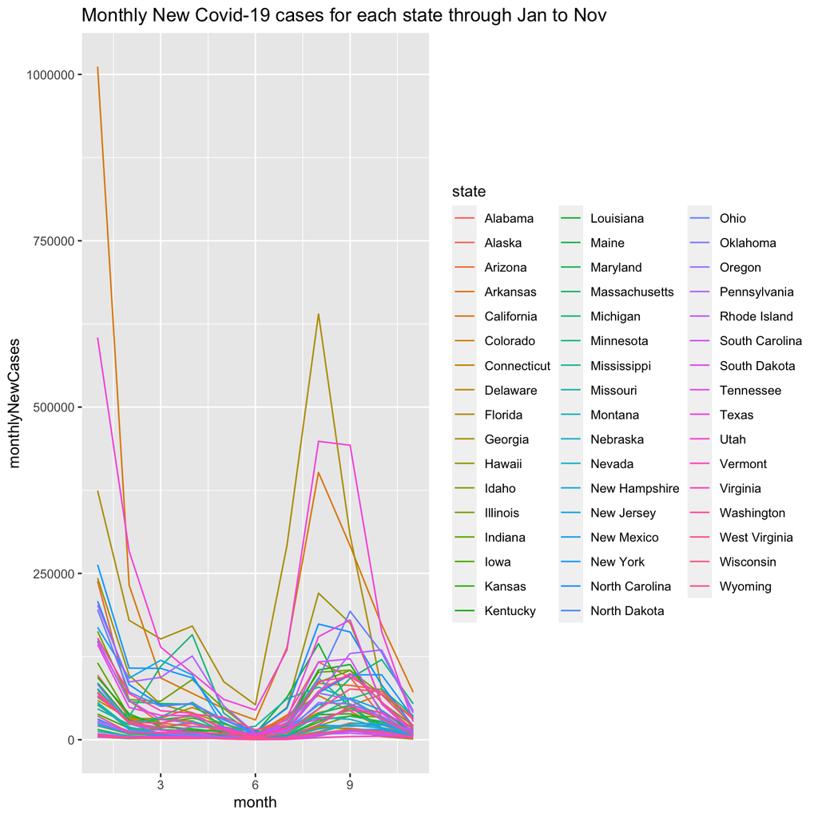

```r
CleanCovidCases %>%
  ggplot(aes(x = month, y = monthlyNewCases))+
  geom_line(aes(color = state))+
  ggtitle("Monthly New Covid-19 cases for each state through Jan to Nov")
```

```r
NA
```

2. Number of people get vaccinated each month for each state through Jan to Nov

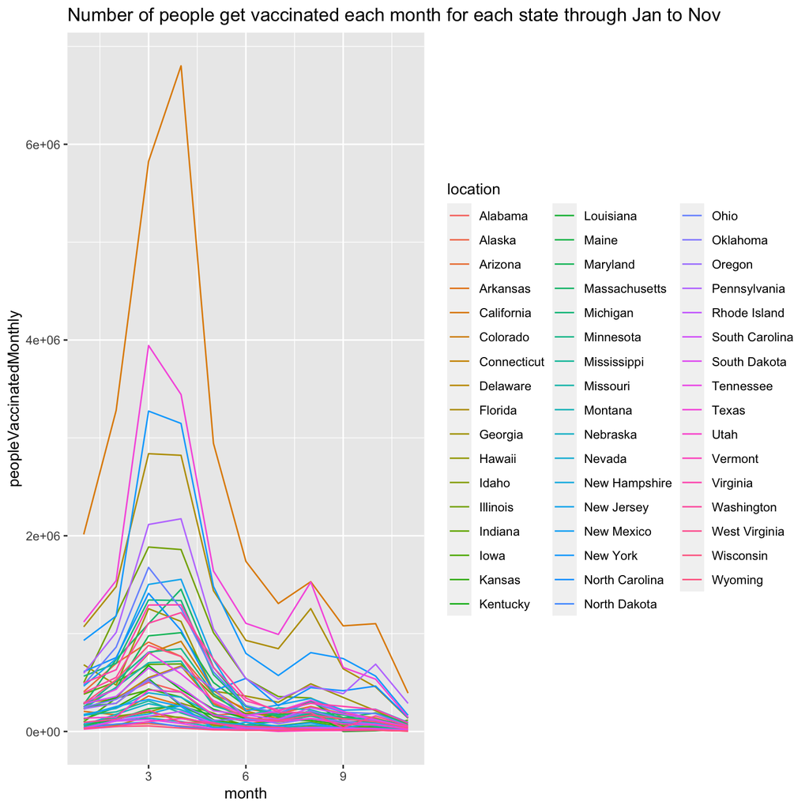

```r
CleanedStateVaccination %>%
  ggplot(aes(x = month, y = peopleVaccinatedMonthly))+
  geom_line(aes(color = location)) +
  ggtitle("Number of people get vaccinated each month for each state through Jan to Nov")
```

```r
NA
NA
```

3. The average number of new covid-19 cases and average number of people get vaccinated for each US region from Jan to Nov.

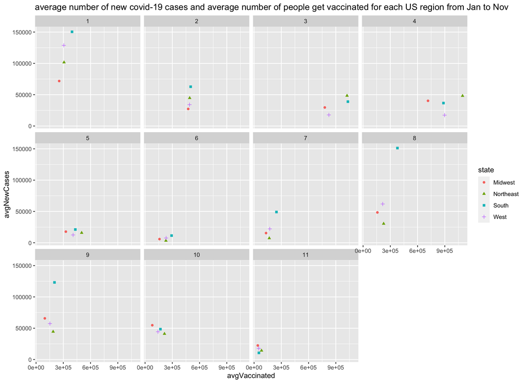

```r
avgRegionData %>%
  ggplot(aes(x = avgVaccinated, y = avgNewCases))+
  geom_point(aes(shape = state, color = state))+
  facet_wrap(~month)+
  ggtitle("average number of new covid-19 cases and average number of people get vaccinated for each US region from Jan to Nov")
```

4. To better visualize and observe patterns, we only take a look at the covid-19 cases here. The average number of new covid-19 cases for each US region from Jan to Nov

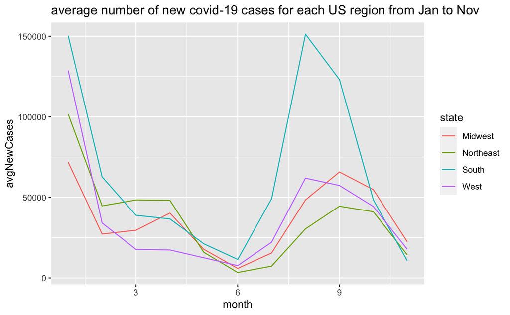

```r
avgRegionData %>%
  ggplot(aes(x = month, y = avgNewCases))+
  geom_line(aes(color = state))+
  ggtitle("average number of new covid-19 cases for each US region from Jan to Nov")
```

```r
NA
NA
```

5. To better visualize and observe patterns, we only take a look at the number of people getting vaccinated here. The average number of people get vaccinated for each US region from Jan to Nov.

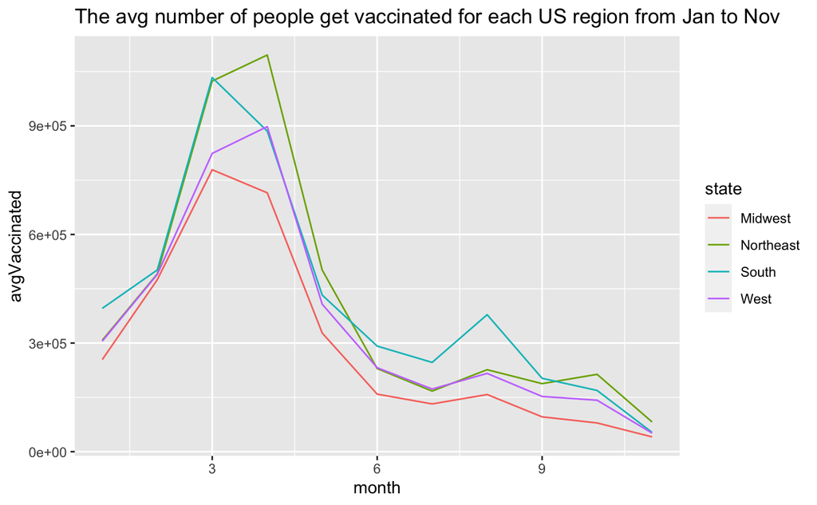

```r
avgRegionData %>%
  ggplot(aes(x = month, y = avgVaccinated))+
  geom_line(aes(color = state)) +
  ggtitle("The avg number of people get vaccinated for each US region from Jan to Nov")
```

```
Mapping API still under development and may change in future releases.
```

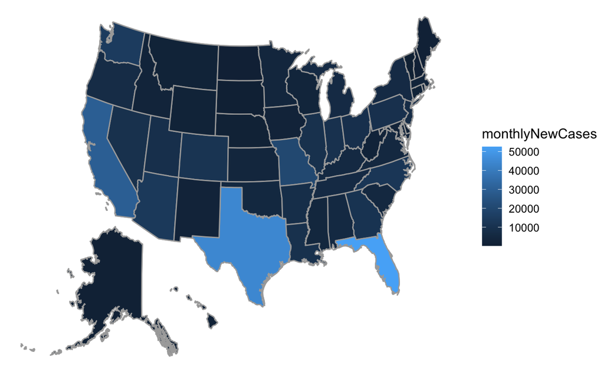

```r
library(mosaic)

CleanCovidCases%>%
  filter(month == 6) %>%
  mUSMap(key = "state", fill = "monthlyNewCases")
```

```
Mapping API still under development and may change in future releases.
```

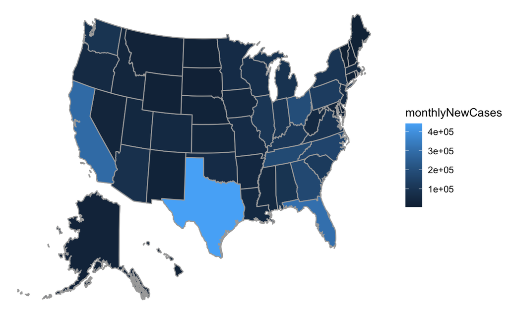

```r
CleanCovidCases%>%
  filter(month == 9) %>%
  mUSMap(key = "state", fill = "monthlyNewCases")
```